# Data Visualization

## Building plots

```r
ggplot(iris, aes(x = Petal.Length, y = Petal.Width, color = Species)) +
  geom_point()
```

- `color = Species` colors points by the *Species* column (a factor)

## Building plots

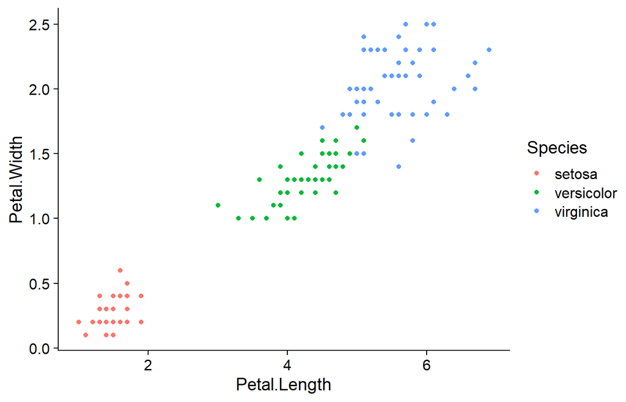

## Building plots

```r
ggplot(iris, aes(x = Petal.Length,
                 y = Petal.Width,
                 shape = Species)) +
  geom_point()
```

- `shape = Species` encodes *Species* by the point shape

## Building plots

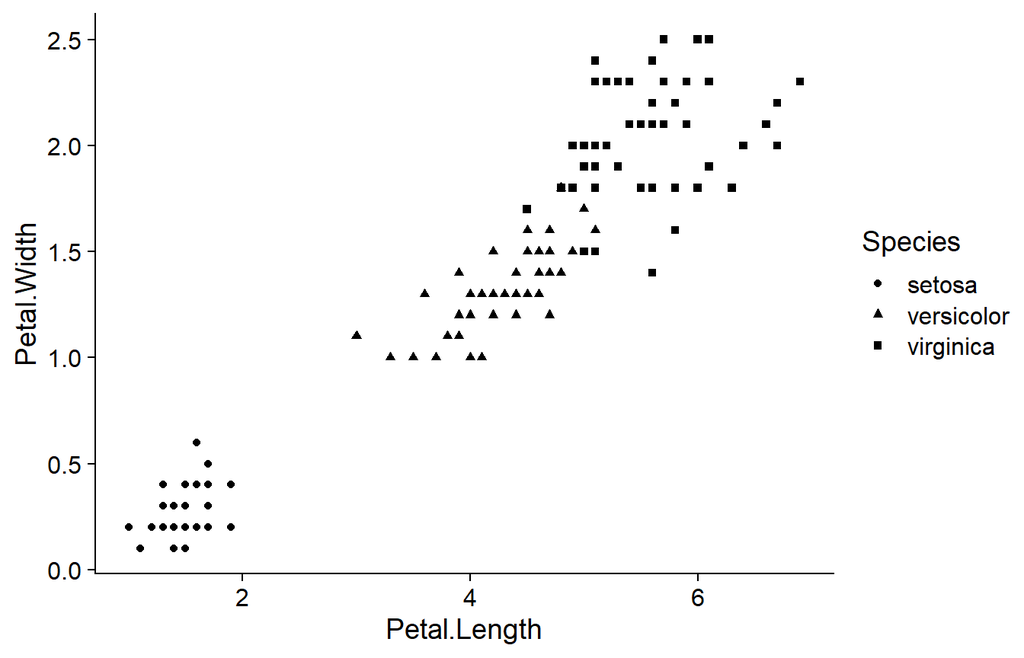

## Building plots

```r
ggplot(iris, aes(x = Petal.Length, y = Petal.Width,
                 color = Species)) +
  geom_point(size = 3)
```

- Change point size

## Building plots

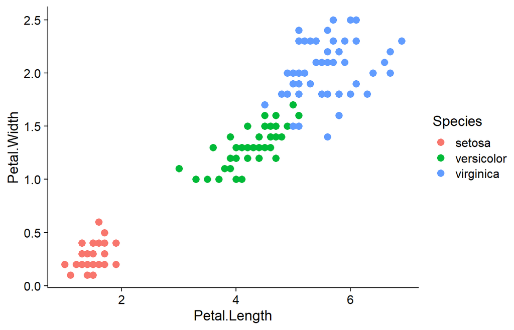

## Building plots

```r
library(wesanderson)
ggplot(iris, aes(x = Petal.Length, y = Petal.Width,
                 color = Species)) +
  geom_point(size = 3) +
  scale_color_manual(values = wes_palette("Moonrise2"))
```

- Add an interesting color palette

## Building plots

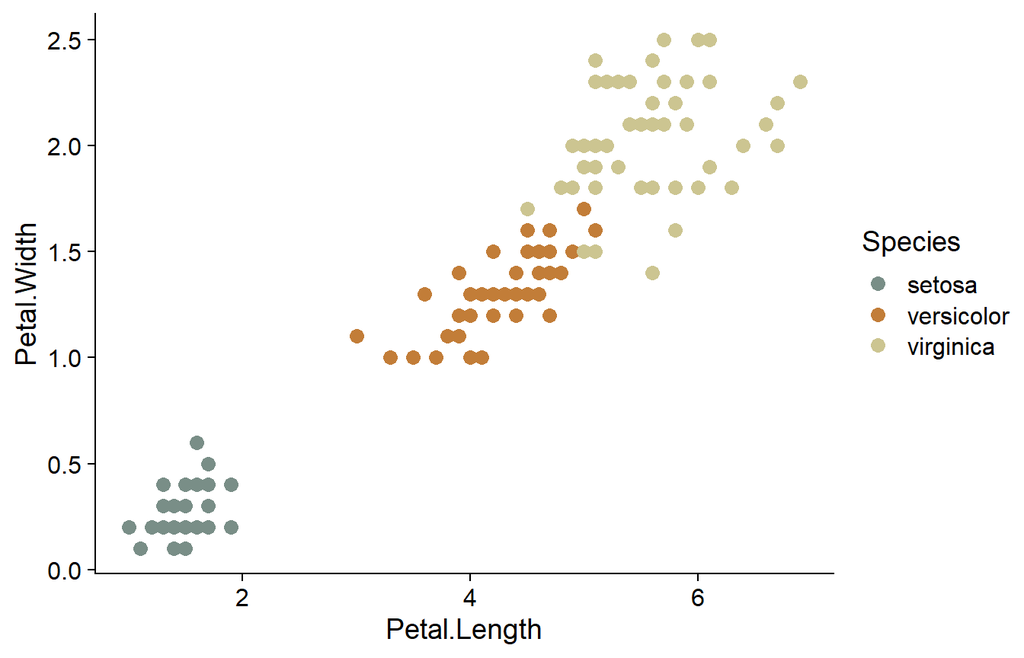

## Building plots

```r
library(viridis)
ggplot(iris, aes(x = Petal.Length, y = Petal.Width,
                 color = Species)) +
  geom_point(size = 3) +
  scale_color_viridis(discrete = TRUE, option = "viridis")
```

- `library(viridis)` works for colorblind and grayscale friendly images.

## Building plots

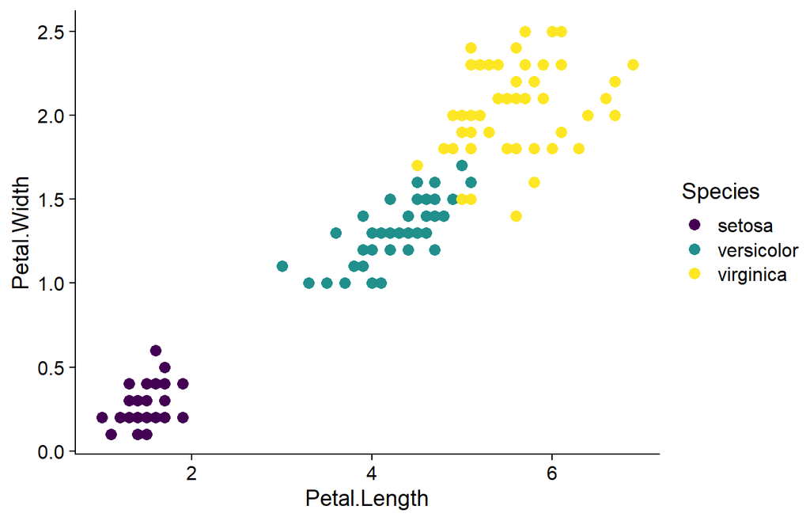

## Building plots

```r
ggplot(iris, aes(x = Petal.Length,
                 y = Petal.Width,
                 color = Species)) +
  geom_point(size = 3) +
  scale_color_manual(values = wes_palette("Moonrise2")) +
  labs(x = "Petal Length (cm)",
       y = "Petal Width (cm)",
       title = "Irises")
```

- Add some better axis labels

## Building plots

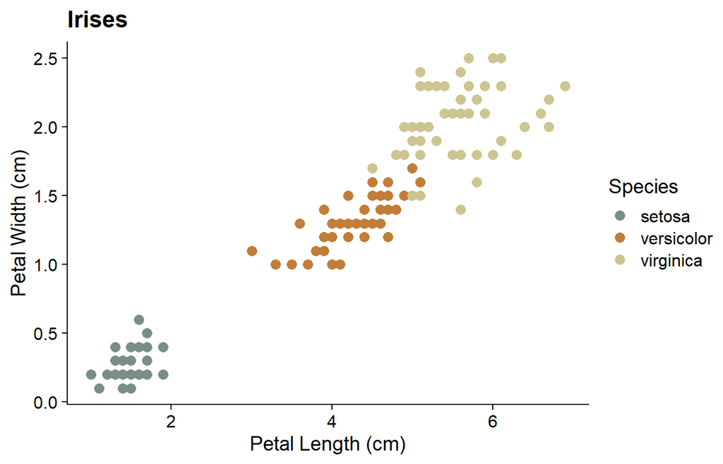

## Adding lines

```r
ggplot(iris, aes(x = Petal.Length, y = Petal.Width)) +
  geom_point() +
  geom_smooth(formula = y ~ x, method = "lm")
```

## Adding lines

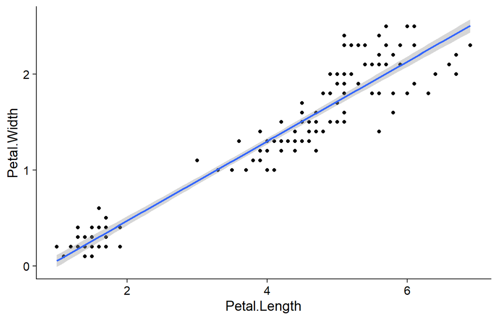

## Adding lines

What if you add a color aesthetic?

```r
ggplot(iris, aes(x = Petal.Length,
                 y = Petal.Width,
                 color = Species)) +
  geom_point() +
  geom_smooth(formula = y ~ x, method = "lm")
```

## Adding lines

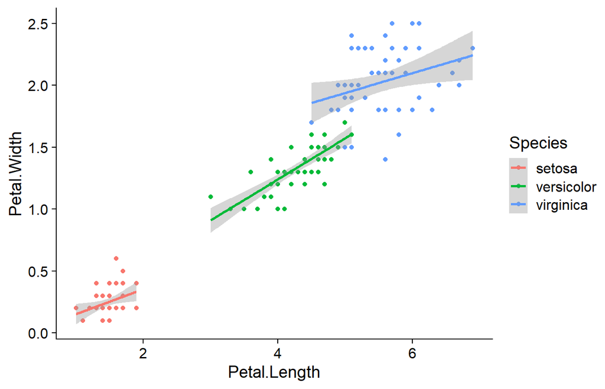

## Log-log axes

```r
ggplot(iris, aes(x = Petal.Length,
                 y = Petal.Width,
                 color = Species)) +
  geom_point() +
  geom_smooth(formula = y ~ x, method = "lm") +
  scale_x_log10() +
  scale_y_log10()
```

## Log-log axes

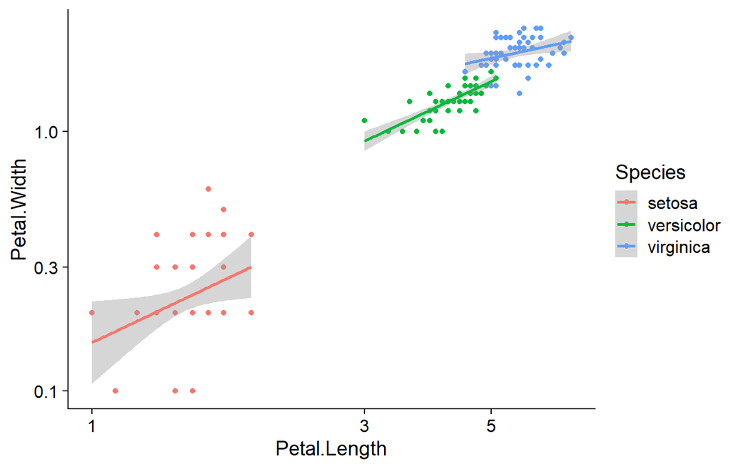

## Facetting

```r
ggplot(iris, aes(x = Petal.Length)) +
  geom_histogram() +
  facet_grid(Species ~ .)
```

- Plots separate histograms for the 3 species in 3 rows
- `facet_grid(. ~ Species)` makes 3 columns

## Facetting

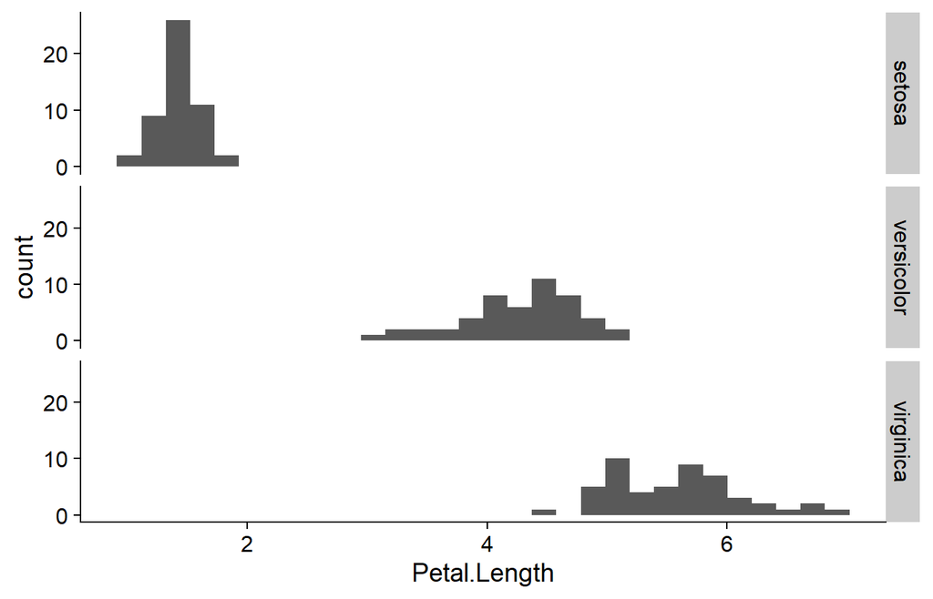

## `_geoms` we will use

- `geom_point()`
- `geom_smooth()`
- `geom_line()`
- `geom_histogram()`
- `geom_density()`
- `geom_boxplot()`
- `geom_dotplot()`